# Reproducible Research Project 1

Parth Pandey

8/6/2020

## Introduction

It is now possible to collect a large amount of data about personal movement using activity monitoring devices such as a [Fitbit](http://www.fitbit.com/), [Nike Fuelband](http://www.nike.com/us/en_us/c/nikeplus-fuelband), or [Jawbone Up](https://jawbone.com/up). These type of devices are part of the “quantified self” movement – a group of enthusiasts who take measurements about themselves regularly to improve their health, to find patterns in their behavior, or because they are tech geeks. But these data remain under-utilized both because the raw data are hard to obtain and there is a lack of statistical methods and software for processing and interpreting the data.

This project makes use of data from a personal activity monitoring device. This device collects data at 5 minute intervals through out the day. The data consists of two months of data from an anonymous individual collected during the months of October and November, 2012 and include the number of steps taken in 5 minute intervals each day.

The data for this project can be downloaded from:

Dataset: [Activity monitoring data](https://d396qusza40orc.cloudfront.net/repdata%2Fdata%2Factivity.zip) [52K]

Now we will load the data and look it

```r
activity<-read.csv("activity.csv")
str(activity)
```

```
## 'data.frame':    17568 obs. of  3 variables:
##  $ steps   : int  NA NA NA NA NA NA NA NA NA NA ...
##  $ date    : chr  "2012-10-01" "2012-10-01" "2012-10-01" "2012-10-01" ...
##  $ interval: int  0 5 10 15 20 25 30 35 40 45 ...
```

```r
summary(activity)
```

```
##      steps            date              interval
##  Min.   :  0.00   Length:17568       Min.   :   0.0
##  1st Qu.:  0.00   Class :character   1st Qu.: 588.8
##  Median :  0.00   Mode  :character   Median :1177.5
##  Mean   : 37.38                      Mean   :1177.5
##  3rd Qu.: 12.00                      3rd Qu.:1766.2
##  Max.   :806.00                      Max.   :2355.0
##  NA's   :2304
```

## Analysis

#### What is mean total number of steps taken per day?

First we sum the total steps per day using `tapply()` function and store the result in `tot_steps_pday`. Then plot the histogram of steps per day

```r
tot_steps_pday<-tapply(activity$steps,activity$date,sum,na.rm=TRUE)
```

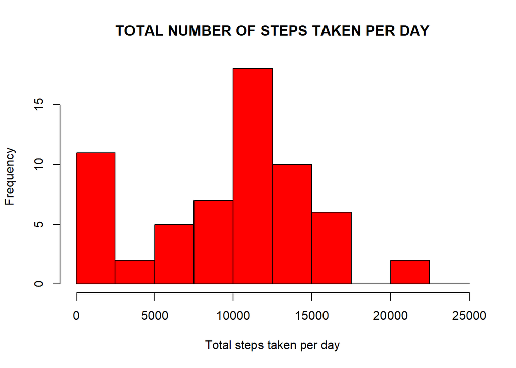

```r
hist(tot_steps_pday,main = "TOTAL NUMBER OF STEPS TAKEN PER DAY",
     xlab="Total steps taken per day",ylab="Frequency",
     col="red",breaks = seq(0,25000,2500))
```

The mean and median of steps per day is:

```
## [1] "Mean= 9354.22950819672"
```

```
## [1] "Median= 10395"
```

#### What is the average daily activity pattern?

We find mean of total steps per interval across all dates using `tapply()` function and store the result in `avg_steps_pint`. Then we make a time series plot of average steps per interval

```r
avg_steps_pint<-tapply(activity$steps,activity$interval,mean,na.rm=TRUE)
avg_steps_pint_table<-cbind(names(avg_steps_pint),avg_steps_pint)
```

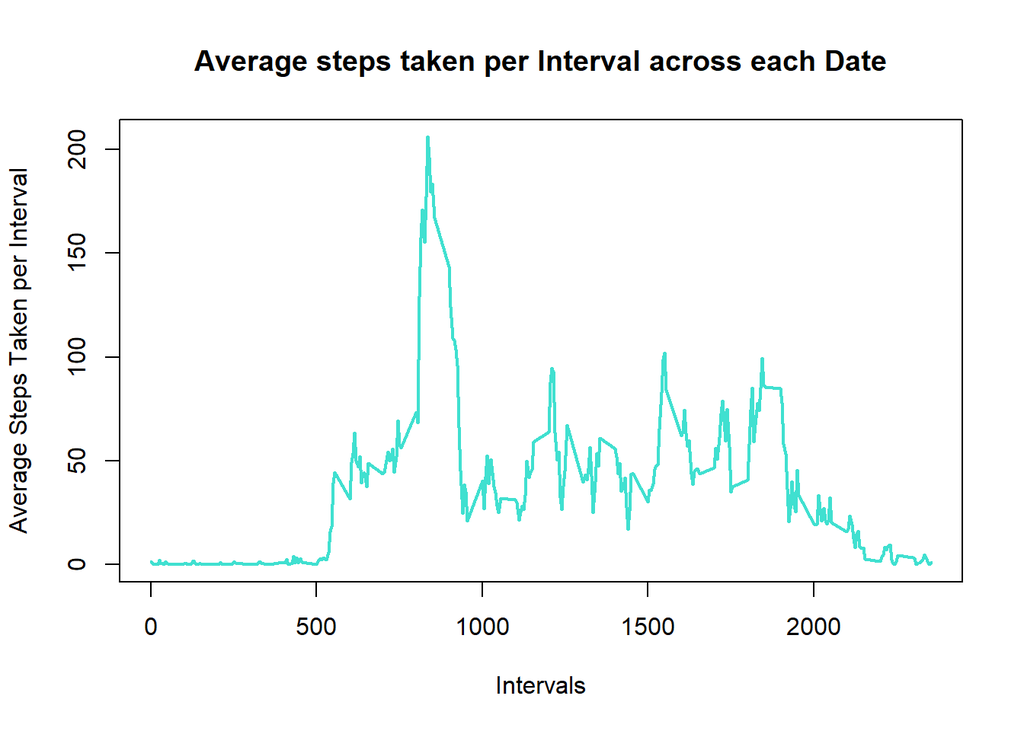

```r
plot(avg_steps_pint_table,main="Average steps taken per Interval across each Date",
     xlab="Intervals",ylab="Average Steps Taken per Interval",
     col="turquoise",type="l",lwd=2)
```

The 5 minute interval, on average across all days, which contains the maximum number of steps is

```
## [1] "835"
```

#### Imputing missing values

Total number of missing values in dataset is

```
## [1] 2304
```

The presence of missing days may introduce bias into some calculations or summaries of the data. So to tackle the situation, a strategy has been devised. All the missing values will be replaced by the mean value of steps of the corresponding interval and the new data in `new_activity`

```r
new_activity<-activity
for(i in 1:nrow(activity)){
  if(is.na(new_activity[i,]$steps)){
    missing_interval<-new_activity[i,]$interval
    new_activity[i,]$steps<-avg_steps_pint[as.character(missing_interval)]
  }
}
```

As new dataset `new_activity` does not contain any missing values, we again plot the histogram of total steps taken each day

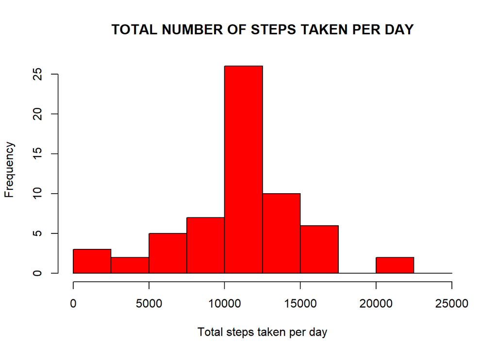

```r
new_tot_steps_pday<-tapply(new_activity$steps,new_activity$date,sum,na.rm=TRUE)
hist(new_tot_steps_pday,main = "TOTAL NUMBER OF STEPS TAKEN PER DAY",
     xlab="Total steps taken per day",ylab="Frequency",
     col="red",breaks = seq(0,25000,2500))
```

Mean and Median of total steps taken per day with respect to `new_activity` is

```
## [1] "Mean= 10766.1886792453"
```

```
## [1] "Median= 10766.1886792453"
```

So, as the missing values are filled, the mean and median has increased significantly.

#### Are there differences in activity patterns between weekdays and weekends?

We have created new variable in the dataset `daytype` which identifies whether the specified `date` falls on **Weekday** or **Weekend** using the function `weekdays()`.

```r
library(lubridate)
new_activity$date<-ymd(new_activity$date)
new_activity$day<-weekdays(new_activity$date)
new_activity$daytype<-"Weekday"
for(i in 1:nrow(new_activity)){
  if(new_activity[i,]$day=="Saturday"|new_activity[i,]$day=="Sunday"){
    new_activity[i,]$daytype<-"Weekend"
  }
}
```

To look at the variations between **Weekday** and **Weekend**, we plot a panel plot of average steps taken per interval across all dates.

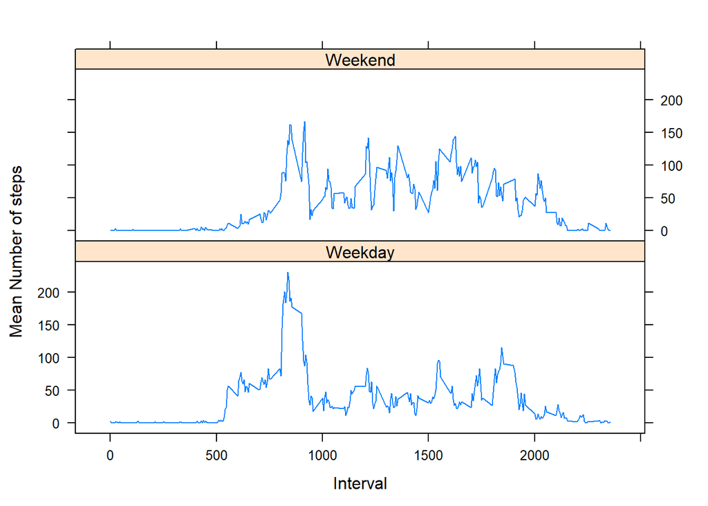

```r
library(dplyr)
library(lattice)
agg_activity<-aggregate(new_activity$steps~new_activity$interval+new_activity$daytype,new_activity,mean)
names(agg_activity)<-c("interval","daytype","steps")
xyplot(steps~interval|daytype,agg_activity,type="l",layout=c(1,2),
       xlab="Interval",ylab="Mean Number of steps")
```

- **To look at the entire code of the above analysis, [click here](https://github.com/parthpandey2000/datasciencecoursera/blob/master/RRProject1.R)**